# Error propagation with correlation

Checking if the covariance term does matter in the error estimation of the stellar masses of galaxies.

Created by Mária Pálfi (marika97@caesar.elte.hu).

## Function for error propagation

We approximate the error with the standard deviation, $\sigma_f$, calculated from

$$\sigma_f^2 \approx \sum_{i=1}^n \left|\frac{\partial f}{\partial x_i}\right|^2 \sigma_i^2 + 2 \cdot \sum_{j=1}^n \sum_{k>j}^n \frac{\partial f}{\partial x_j} \frac{\partial f}{\partial x_k} \sigma_j \sigma_k \rho_{ij}, $$

where $f$ is a function of $x_i$ variables with $\sigma_i$ uncertainty, $\rho$ is the correlation coefficient of $i$ and $j$ variable.

## Stellar mass estimation methods

### Cluver's method

According to Cluver et al. 2014 (Cluver, M. E., et al. 2014, The Astrophysical Journal, 782, 90 doi:10.1088/0004-637X/782/2/90), we can estimate the stellar mass with the following equation:

$$lg (M_{stellar} /L_{W1} ) = −1.96(W1 − W2 ) − 0.03,$$

where

$$L_{W1} (L_{Sun}) = 10^{−0.4(M −M_{Sun} )},$$

$$M_{Sun} = 3.24$$

$M$ is the absolute magnitude measured in the W1 filter, $W1-W2$ is rest-frame color.

$$M_\ast = 10^{-(1.96+0.4)\cdot(m_\text{W1}+5-5\lg d +2.5854 z)+1.96\cdot(m_\text{W2}+5-5\lg d +2.9358 z )+ 0.4 \cdot 3.24 - 0.03 }.$$

**Partial derivatives:**

$$\frac{\partial M_\ast}{\partial m_{W1}} = -2.36 \cdot M_\ast \cdot \ln|10|,$$$$\frac{\partial M_\ast}{\partial m_{W2}} = 1.96 \cdot M_\ast \cdot \ln|10|,$$$$ \frac{\partial M_\ast}{\partial d} = M_\ast \cdot \ln|10| \cdot \frac{2}{d \cdot \ln(10)} = \frac{2 \cdot M_\ast}{d},$$$$ \frac{\partial M_\ast}{\partial z} = M_\ast \cdot \ln|10| \cdot [-2.36 \cdot 2.5854 + 1.96 \cdot 2.9358 ] = -0.3454 \cdot M_\ast \cdot \ln|10|.$$

If there is no magnitude error, I use the mean $\Delta m$.

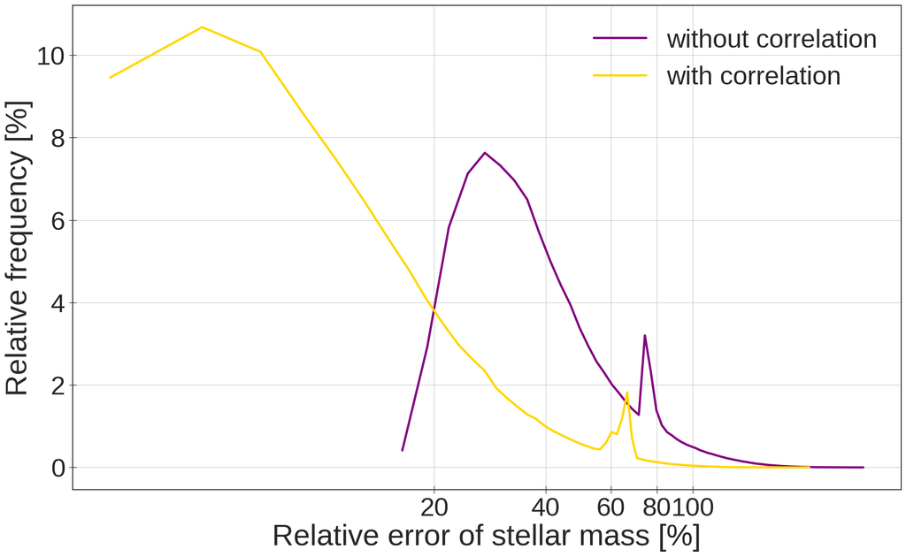

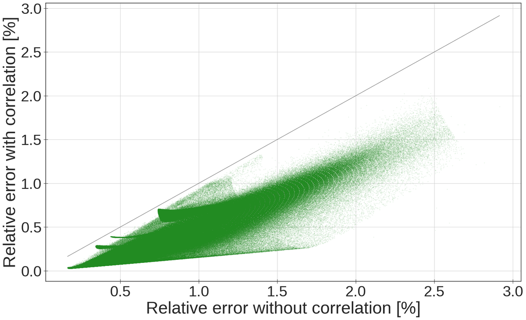